# **Kramers-protected error correction with Andreev sp n qub ts**

## Why are ASQ challenging?

## How to make ASQ more robust?

### Kramers' theorem

Eigenstates of a **time-reversal symmetric** system with **half-integer spin** come in degenerate pairs.

### Kramers' theorem

At fluxes the eigenstates of the Hamiltonian are degenerate

$$\varphi=0,\pi$$

\varphi=0,\pi

Therefore, we need a magnetic field or a drive to implement gates

### Design: ASQ in a network of inductors

Kramers theorem forces a degenerate computational space at TRS flux

$$\lvert 0_L \rangle$$

\lvert 0_L \rangle

$$\lvert 1_L \rangle$$

\lvert 1_L \rangle

$$H_{\sigma} = J_{12} \sigma_{1,z} \sigma_{2,z} + J_{23} \sigma_{2,z} \sigma_{3,z} + J_{13} \sigma_{1,z} \sigma_{3,z}$$

H_{\sigma} = J_{12} \sigma_{1,z} \sigma_{2,z} + J_{23} \sigma_{2,z} \sigma_{3,z} + J_{13} \sigma_{1,z} \sigma_{3,z}

### A repetition error-correcting code

\lvert 0_L \rangle

\lvert 1_L \rangle

H_{\sigma} = J_{12} \sigma_{1,z} \sigma_{2,z} + J_{23} \sigma_{2,z} \sigma_{3,z} + J_{13} \sigma_{1,z} \sigma_{3,z}

Protection against bit flip errors because:

- A bit flip error is a non-local operation

- Flipping a spin requires breaking TRS

- Hamiltonian is composed of stabilizers

### Dispersive readout via network inductance

$$H_r = \hbar \omega_{r,0} a^\dagger a + \sum_{i \neq j} \hbar \chi_{ij} \sigma_{i,z}\sigma_{j,z}a^\dagger a$$

H_r = \hbar \omega_{r,0} a^\dagger a + \sum_{i \neq j} \hbar \chi_{ij} \sigma_{i,z}\sigma_{j,z}a^\dagger a

$$H_{\sigma} = J_{12} \sigma_{1,z} \sigma_{2,z} + J_{23} \sigma_{2,z} \sigma_{3,z} + J_{13} \sigma_{1,z} \sigma_{3,z}$$

H_{\sigma} = J_{12} \sigma_{1,z} \sigma_{2,z} + J_{23} \sigma_{2,z} \sigma_{3,z} + J_{13} \sigma_{1,z} \sigma_{3,z}

A single readout resonator detects bip flips

### Dispersive readout via network inductance

$$H_r = \hbar \omega_{r,0} a^\dagger a + \sum_{i \neq j} \hbar \chi_{ij} \sigma_{i,z}\sigma_{j,z}a^\dagger a$$

H_r = \hbar \omega_{r,0} a^\dagger a + \sum_{i \neq j} \hbar \chi_{ij} \sigma_{i,z}\sigma_{j,z}a^\dagger a

$$H_{\sigma} = J_{12} \sigma_{1,z} \sigma_{2,z} + J_{23} \sigma_{2,z} \sigma_{3,z} + J_{13} \sigma_{1,z} \sigma_{3,z}$$

H_{\sigma} = J_{12} \sigma_{1,z} \sigma_{2,z} + J_{23} \sigma_{2,z} \sigma_{3,z} + J_{13} \sigma_{1,z} \sigma_{3,z}

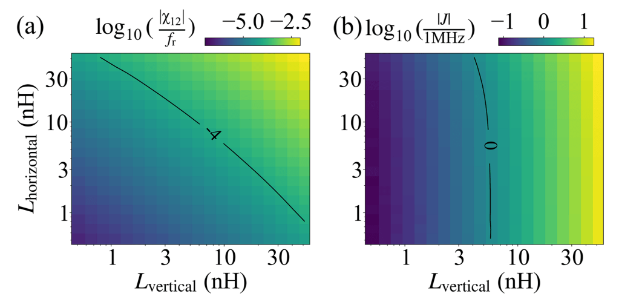

### Logical gates

$$U_{\sigma} = E_J \cos(\phi) + E_{\sigma} ([\vec{\epsilon_{SO}} + \delta \vec{\epsilon_{SO}} \cos(\omega t)]\cdot \vec{\sigma}) \sin(\phi)$$

U_{\sigma} = E_J \cos(\phi) + E_{\sigma} ([\vec{\epsilon_{SO}} + \delta \vec{\epsilon_{SO}} \cos(\omega t)]\cdot \vec{\sigma}) \sin(\phi)

- using EDSR to drive each spin

- using adiabatic flux detuning

$$R_x(\theta)$$

R_x(\theta)

$$R_z(\theta)$$

R_z(\theta)

$$\theta = \hbar^{-1} \int_0^T dt (E_{\lvert 0_L \rangle}(\Phi_t) - E_{\lvert 1_L \rangle}(\Phi_t) )$$

\theta = \hbar^{-1} \int_0^T dt (E_{\lvert 0_L \rangle}(\Phi_t) - E_{\lvert 1_L \rangle}(\Phi_t) )

## Conclusions

- Proof of principle of repetition error-correcting code with ASQ

- Materials with which to make the junctions remain a challenge